# assignment5

Florence Marti

2025-03-24

```r
suppressPackageStartupMessages({
  library(AnnotationHub)
  library(ensembldb)
  library(GenomicRanges)
  library(epiwraps)
  library(rtracklayer)
  library(ggplot2)
  library(magick)
  library(R.utils) #for function gunzip
  library(MASS)
})
```

Using peaks from ENCODE, identify bivalent domains (H3K27me3 + H3K4me3) from (mouse or human) embryonic stem cells (ESC) Question: what happens to those regions upon differentiation? Choose one differentiated cell type (e.g. erythroblasts, fibroblast, B cells, etc.) Download the H3K27me3 and H3K4me3 peaks from this cell type

How many of the mESC bivalent domains are, in this differentiated cell type, overlapping either mark or their combination (in this differentiated cell type)? # 1. Undifferentiated peaks

```r
dir.create("peaks_assignment/mESC")
download.file("https://www.encodeproject.org/files/ENCFF558YNC/@@download/ENCFF558YNC.bed.gz", destfile="peaks_assignment/mESC/mESC_H3K27me3.bed.gz")
gunzip("peaks_assignment/mESC/mESC_H3K27me3.bed.gz")
##import peaks
mESC_H3K27me3 <- rtracklayer::import("peaks_assignment/mESC/mESC_H3K27me3.bed", format ="narrowPeak")
head(mESC_H3K27me3)
```

```
## GRanges object with 6 ranges and 6 metadata columns:
##       seqnames              ranges strand |        name     score signalValue
##          <Rle>           <IRanges>  <Rle> | <character> <numeric>   <numeric>
##   [1]    chr10 100014187-100014494      * |  Peak_28650        81     3.69750
##   [2]    chr10 100015532-100015655      * |   Peak_5611       169     4.26535
##   [3]    chr10 100016946-100017406      * |  Peak_92083        29     2.17536
##   [4]    chr10 100017627-100017784      * |  Peak_22317       104     3.80506
##   [5]    chr10 100017952-100018173      * |  Peak_28651        81     3.69750
##   [6]    chr10 100681843-100681994      * |  Peak_10089       132     4.62188
##          pValue    qValue      peak
##       <numeric> <numeric> <integer>
##   [1]   4.52516   1.43442       229
##   [2]   7.69425   3.86512        65
##   [3]   2.71268   0.40010       454
##   [4]   5.30568   2.06055        75
##   [5]   4.52516   1.43442       153
##   [6]   6.35893   2.81597        54
##   -------
##   seqinfo: 26 sequences from an unspecified genome; no seqlengths
```

```r
download.file("https://www.encodeproject.org/files/ENCFF974BMC/@@download/ENCFF974BMC.bed.gz", destfile="peaks_assignment/mESC/mESC_H3K4me3.bed.gz")
gunzip("peaks_assignment/mESC/mESC_H3K4me3.bed.gz")
##import peaks
mESC_H3K4me3 <- rtracklayer::import("peaks_assignment/mESC/mESC_H3K4me3.bed", format ="narrowPeak")
head(mESC_H3K4me3)
```

```
## GRanges object with 6 ranges and 6 metadata columns:
##       seqnames            ranges strand |        name     score signalValue
##          <Rle>         <IRanges>  <Rle> | <character> <numeric>   <numeric>
##   [1]     chr1 10008752-10009380      * |  Peak_23885       428    11.23695
##   [2]     chr1 10009664-10009896      * |  Peak_50994        75     3.00446
##   [3]     chr1 10037300-10038732      * |    Peak_214      1000    37.07471
##   [4]     chr1 10038883-10039286      * |  Peak_22909       469     9.20144
##   [5]     chr1 10039462-10039636      * |  Peak_35096       176     4.65032
##   [6]     chr1 10039770-10040401      * |  Peak_14172      1000    17.29300
##          pValue    qValue      peak
##       <numeric> <numeric> <integer>
##   [1]  42.84213  40.39541       299
##   [2]   7.55824   5.49208       122
##   [3] 380.32788 374.89581       530
##   [4]  46.95513  44.47808       231
##   [5]  17.66225  15.43799        91
##   [6] 109.33575 106.46882       126
##   -------
##   seqinfo: 21 sequences from an unspecified genome; no seqlengths
```

```r
# to read several peak files:
# first list the files:
peakfiles_assignment_mESC <- list.files("peaks_assignment/mESC", full.names = TRUE)
# then give them meaningful names
names(peakfiles_assignment_mESC) <- gsub("\\.bed","",basename(peakfiles_assignment_mESC))

# then loop through them and read them:
peaks_assignment_mESC <- lapply(peakfiles_assignment_mESC, FUN=rtracklayer::import, format="narrowPeak")
```

```r
bivDomains_mESC <- overlapsAny(mESC_H3K4me3, mESC_H3K27me3) # Question: Why does the order of files in OverlapsAny matter?
sum(bivDomains_mESC)
```

```
## [1] 3504
```

```r
bivDomain_mESC_peaks <- findOverlaps(mESC_H3K4me3, mESC_H3K27me3, type = "any")
head(bivDomain_mESC_peaks)
```

```
## Hits object with 6 hits and 0 metadata columns:
##       queryHits subjectHits
##       <integer>   <integer>
##   [1]         8         673
##   [2]        11         681
##   [3]        12         683
##   [4]        32         687
##   [5]        46         690
##   [6]        47         691
##   -------
##   queryLength: 51079 / subjectLength: 16648
```

```r
#Extracting the subset of bivalent domains (same amount as in the OverlapsAny)
subset <- mESC_H3K4me3[bivDomains_mESC[TRUE]]
head(subset)
```

```
## GRanges object with 6 ranges and 6 metadata columns:
##       seqnames              ranges strand |        name     score signalValue
##          <Rle>           <IRanges>  <Rle> | <character> <numeric>   <numeric>
##   [1]     chr1   10231731-10233519      * |  Peak_10814      1000    28.34326
##   [2]     chr1 104993805-104994492      * |  Peak_19916       624    10.33051
##   [3]     chr1 105355437-105357116      * |   Peak_7721      1000    27.59842
##   [4]     chr1 106713477-106714313      * |   Peak_9604      1000    37.55338
##   [5]     chr1   10993429-10994211      * |  Peak_13262      1000    15.70914
##   [6]     chr1   10994251-10994552      * |  Peak_41439       120     5.14364
##          pValue    qValue      peak
##       <numeric> <numeric> <integer>
##   [1]  145.7372 142.64072      1228
##   [2]   62.4458  59.86532       311
##   [3]  184.6294 181.26285       869
##   [4]  160.4227 157.22754       296
##   [5]  119.3918 116.46281       438
##   [6]   12.0377   9.88982       102
##   -------
##   seqinfo: 21 sequences from an unspecified genome; no seqlengths
```

```r
length(subset)
```

```
## [1] 3504
```

## Cells used: Mouse Erythroblasts (E14.5)

### Histone 3 Lysine 4 Tri-Methylation

```r
dir.create("peaks_assignment/mEry")
download.file("https://www.encodeproject.org/files/ENCFF339CXH/@@download/ENCFF339CXH.bed.gz", destfile="peaks_assignment/mEry/H3K4me3.bed.gz")
gunzip("peaks_assignment/mEry/H3K4me3.bed.gz")
```

### Histone 3 Lysine 27 Tri-Methylation

I chose this dataset because the one above also had replicated peaks and this one does as well - I don’t know if it makes a difference whether the peaks are replicated or pseudoreplicated, but if it does, could we discuss this in class next week?

```r
download.file("https://www.encodeproject.org/files/ENCFF684IRJ/@@download/ENCFF684IRJ.bed.gz", destfile="peaks_assignment/mEry/H3K27me3.bed.gz")
gunzip("peaks_assignment/mEry/H3K27me3.bed.gz")
```

```r
# to read several peak files:
# first list the files:
peakfiles_assignment <- list.files("peaks_assignment/mEry", full.names = TRUE)
# then give them meaningful names
names(peakfiles_assignment) <- gsub("\\.bed","",basename(peakfiles_assignment))

# then loop through them and read them:
peaks_assignment <- lapply(peakfiles_assignment, FUN=rtracklayer::import, format="narrowPeak")


bivDomains_mEry <- overlapsAny(peaks_assignment$H3K4me3, peaks_assignment$H3K27me3)
sum(bivDomains_mEry)
```

```
## [1] 6695
```

## Upset Plot of the mESC

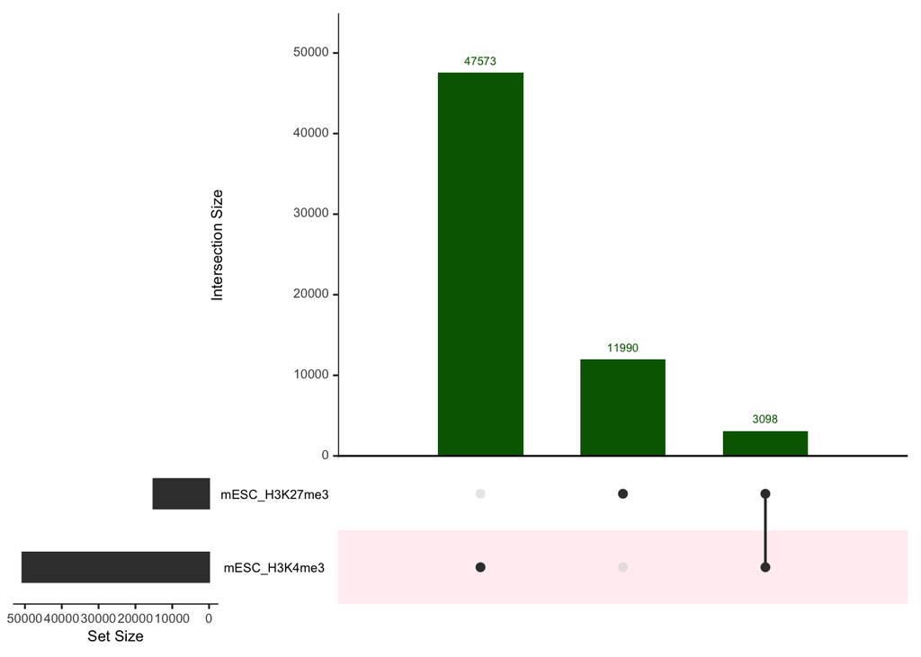

```r
regionUpset(peaks_assignment_mESC, nsets=length(peaks_assignment_mESC), main.bar.color = "darkgreen", shade.color = "pink")
```

## Upset Plot for Erythrocytes and Bivalent Domains

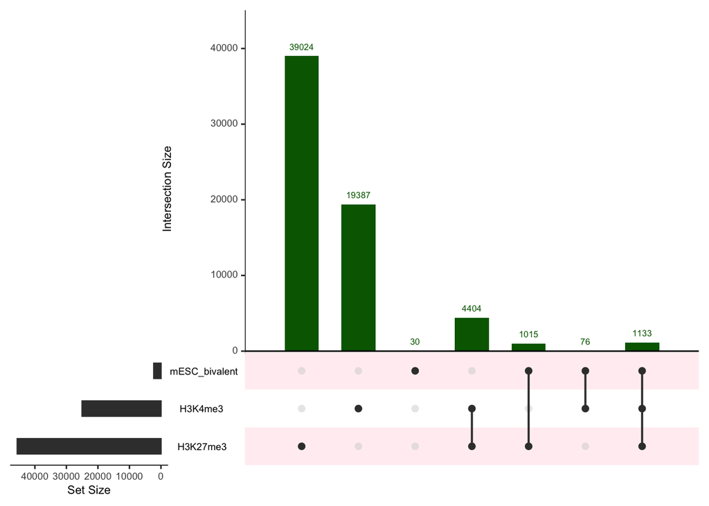

```r
peaks_assignment$mESC_bivalent <- subset
regionUpset(peaks_assignment, nsets=length(peaks_assignment), main.bar.color = "darkgreen", shade.color = "pink")
```

Out of the histone modifications that used to be bivalent, fewer are still bivalent (decrease from 3098 to 1133). This can be explained by the differentation of the cells to erythrocytes, which have a different phenotype and also different tasks compared to stem cells. Out of the formerly bivalent histone modification sites, 1015 have turned to H3K27me3 and 76 have become H3K4me3. 30 of the formerly bivalent domains have no match for either K27me3 or K4me3. However, 4404 formerly non bivalent domains are now bivalent.